# Python 資料科學學習手冊

> Python 資料科學模組

[數聚點](https://www.datainpoint.com) | 郭耀仁 yaojenkuo@datainpoint.com

## 關於模組

## 什麼是模組

模組（Module）指的是以檔案或資料夾形式，來組織 Python 的函數以及類別。檔案形式可以對應「數個函數或類別可以組織為一個模組」層次、資料夾形式可以對應「數個模組可以組織為一個功能更多的模組」層次。

## 模組有三個來源

1. **標準模組**。
2. **來自使用者的定義**。
3. 第三方模組。

## 標準模組（Standard libraries）

- 伴隨 Python 直譯器（來自 python.org 的版本）安裝的模組。
- 可以直接載入並使用。
- 有哪些標準模組可以直接載入並使用：https://docs.python.org/3/library

## 如何載入模組

## 使用 `import`、`from` 與 `as` 保留字

- 使用 `import` 載入模組。
- 使用 `from module import function/class` 載入模組中特定的函數或類別。
- 使用 `as` 調整模組、函數或者類別的命名。

## 使用 `import` 載入模組

- 以 `module` 命名使用。
- 使用模組中的函數、類別時都以 `module.function()` 或 `module.class()` 來參照命名。

```
import module

module.function()
object = module.class()
```

```python
import os

os.getcwd()
```

```
'/Users/kuoyaojen/classroom-python-for-cht'
```

```python
import datetime

first_day_of_2022 = datetime.date(2022, 1, 1)
print(first_day_of_2022)
```

```
2022-01-01
```

## 使用 `from module import function/class` 載入模組中特定的函數或類別

載入特定函數或類別，就直接以 `function()` 或 `class()` 來參照命名。

```
from module import function
from module import class

function()
object = class()
```

```python
from os import getcwd

getcwd()
```

```
'/Users/kuoyaojen/classroom-python-for-cht'
```

```python
from datetime import date

first_day_of_2022 = date(2022, 1, 1)
print(first_day_of_2022)
```

```
2022-01-01
```

## 使用 `as` 調整模組、函數或者類別的命名

```
import module as module_alias
from module import function as function_alias
from module import class as class_alias

module_alias.function()
function_alias()
object = class_alias()
```

```python
import os as operating_system
from os import getcwd as get_current_working_directory

print(operating_system.getcwd())
print(get_current_working_directory())
```

```
/Users/kuoyaojen/classroom-python-for-cht
/Users/kuoyaojen/classroom-python-for-cht
```

```python
import datetime as dttm
from datetime import date as dt

first_day_of_2022 = dttm.date(2022, 1, 1)
print(first_day_of_2022)
first_day_of_2022 = dt(2022, 1, 1)
print(first_day_of_2022)
```

```
2022-01-01
2022-01-01
```

## 如何決定模組載入的形式

- `import module`
- `import module as alias`
- `from module import function/class`
- `from module import function/class as alias`

## 如何決定模組載入的形式（續）

- 依照模組說明文件（Documentation）中的範例決定。
- 例如：使用 `os` 模組時採用 `import os`
- 例如：使用 `datetime` 模組時採用 `from datetime import function/class`

來源：https://docs.python.org/3/library/os.html#file-object-creation, https://docs.python.org/3/library/datetime.html#examples-of-usage-date

```python
import os

os.getcwd()
```

```
'/Users/kuoyaojen/classroom-python-for-cht'
```

```python
from datetime import date

first_day_of_2022 = date(2022, 1, 1)
print(first_day_of_2022)
```

```
2022-01-01
```

## 為什麼模組名稱可以被認得

- Python 會搜尋標準模組的安裝路徑中是否有檔名為 `datetime.py`、`os.py`、`this.py` 或資料夾名稱 `this`、`os`、`datetime`（事實上這裡舉例的模組形式均為檔案名稱）。
- 如果沒有，就會產生找不到模組錯誤（`ModuleNotFoundError`）。
- 如果有，就會依據指令載入裡面全部或特定的函數與類別。

```python
# There is a this.py, but no that.py
try:
    import that
except ModuleNotFoundError as error_message:
    print(error_message)
```

```
No module named 'that'
```

## 關於 NumPy

## 什麼是 NumPy

> NumPy 是 Numeric Python 的簡稱，是 Python 最重要的資料科學模組之一。NumPy 創造了 `ndarray` 的資料結構類別以及大量的通用函數與聚合函數，讓 Python 使用者能夠對進行快速的數值計算、使用統計函數、進行線性代數運算以及操作隨機的模擬任務等。

來源：https://numpy.org/

## 根據說明文件的範例載入

來源：https://numpy.org/doc/stable/user/absolute_beginners.html#how-to-import-numpy

```python
import numpy as np
```

## NumPy 的核心功能

1. 使用 `ndarray` 來進行數值操作。
2. 使用模組定義的函數對 `ndarray` 進行數值運算。
3. `ndarray` 是其他資料科學模組 Pandas、Matplotlib 與 Scikit-Learn 的基石。

## 如何創造 `ndarray`

## 從 `list` 創造 `ndarray`

```python
prime_list = [2, 3, 5, 7, 11]
prime_array = np.array(prime_list)
print(prime_array)
print(type(prime_array))
```

```
[ 2  3  5  7 11]
<class 'numpy.ndarray'>
```

## 利用 NumPy 函數創造內容元素相同的 `ndarray`

- `np.zeros()`
- `np.ones()`
- `np.full()`

```python
print(np.zeros(5, dtype=int))
print(np.ones(5, dtype=float))
print(np.full(5, 6))
```

```
[0 0 0 0 0]
[1. 1. 1. 1. 1.]
[6 6 6 6 6]
```

## 利用 NumPy 函數創造數列型態的 `ndarray`

- `np.arange(start, stop, step)`
- `np.linspace(start, stop, num)` 值得注意的是 `stop` 參數預設為包含。

```python
print(np.arange(1, 11, 2))
print(np.linspace(1, 9, 5, dtype=int))
```

```
[1 3 5 7 9]
[1 3 5 7 9]
```

## 利用 `np.random` 中的函數創造隨機性的 `ndarray`

```python
m = 10000
uniform_array = np.random.random(m) # module.function()
normal_array = np.random.normal(0, 1, m)
randint_array = np.random.randint(1, 7, size=m)
print(uniform_array)
print(normal_array)
print(randint_array)
```

```
[0.3632697  0.58198865 0.70267954 ... 0.8822216  0.66284069 0.46572408]
[ 0.89433502  1.58831199  0.91970804 ...  0.05247824  0.17686699
 -0.88366516]
[6 6 5 ... 3 3 4]
```

## 常用的 `ndarray` 屬性

- `ndarray.ndim` 維度數。
- `ndarray.shape` 外型。
- `ndarray.size` 元素個數。
- `ndarray.dtype` 資料類別。

```python
prime_list = [2, 3, 5, 7, 11]
prime_array = np.array(prime_list)
print(prime_array.ndim)
print(prime_array.shape)
print(prime_array.size)
print(prime_array.dtype)
```

```
1
(5,)
5
int64
```

## 不同維度數的 `ndarray` 有不同的暱稱

- 零維 `ndarray`：純量（Scalar）。
- 一維 `ndarray`：向量（Vector）。
- 二維 `ndarray`：矩陣（Matrix）。
- 三維或者 n 維 `ndarray`：張量（Tensor）。

## 純量、向量、矩陣與張量外型示意圖

[figure not shown]

來源：https://dev.to/juancarlospaco/tensors-for-busy-people-315k

```python
scalar = np.array(5566)
print(scalar)
print(scalar.ndim)
print(scalar.shape)
```

```
5566
0
()
```

```python
vector = np.array([5, 5, 6, 6])
print(vector)
print(vector.ndim)
print(vector.shape)
```

```
[5 5 6 6]
1
(4,)
```

```python
matrix = np.array([[5, 5],
                   [6, 6],
                   [55, 66]])
print(matrix)
print(matrix.ndim)
print(matrix.shape) # (m, n)
```

```
[[ 5  5]
 [ 6  6]
 [55 66]]
2
(3, 2)
```

```python
tensor = np.array([[[5, 5],
                    [6, 6],
                    [55, 66]],
                   [[5, 5],
                    [6, 6],
                    [55, 66]],
                   [[5, 5],
                    [6, 6],
                    [55, 66]],
                   [[5, 5],
                    [6, 6],
                    [55, 66]]])
print(tensor)
print(tensor.ndim)
print(tensor.shape) # (l, m, n)
```

```
[[[ 5  5]
  [ 6  6]
  [55 66]]

 [[ 5  5]
  [ 6  6]
  [55 66]]

 [[ 5  5]
  [ 6  6]
  [55 66]]

 [[ 5  5]
  [ 6  6]
  [55 66]]]
3
(4, 3, 2)
```

## `ndarray` 與 `list` 的異同

## `ndarray` 與 `list` 相同的地方

- indexing/slicing 的語法。
- 能夠以 indexing 更新。

## indexing 的語法

`ndarray` 採用兩個方向的索引機制：

1. 由左至右：「從 0 開始」的索引機制。
2. 由右至左：「從 -1 開始」的索引機制。

```python
primes_array = np.array([2, 3, 5, 7, 11])
print("From start to stop:")
print(primes_array[0])
print(primes_array[1])
print(primes_array[2])
print(primes_array[3])
print(primes_array[primes_array.size - 1])
print("From stop to start:")
print(primes_array[-1])
print(primes_array[-2])
print(primes_array[-3])
print(primes_array[-4])
print(primes_array[-primes_array.size])
```

```
From start to stop:
2
3
5
7
11
From stop to start:
11
7
5
3
2
```

## slicing `[start:stop:step]`

除了可以取出特定位置的單個資料值，`ndarray` 也支援擷取特定片段，藉此獲得一個較短長度 `ndarray` 的語法。

- `start` 起始位置（包含）。
- `stop` 終止位置（排除）。
- `step` 間隔。

```python
print(primes_array[::])   # default
print(primes_array[::2])  # step=2
print(primes_array[:3])   # stop=5, exclusive
print(primes_array[3:])   # start=5, inclusive
print(primes_array[::-1]) # step=-1, reverse
```

```
[ 2  3  5  7 11]
[ 2  5 11]
[2 3 5]
[ 7 11]
[11  7  5  3  2]
```

## 能夠以 indexing 更新

```python
primes_array = np.array([2, 3, 5, 7, 11])
print(primes_array)   # before update
primes_array[-1] = 13 # update
print(primes_array)   # after update
```

```
[ 2  3  5  7 11]
[ 2  3  5  7 13]
```

## `ndarray` 與 `list` 相異的地方

- indexing 二維以上的 `ndarray` 可以用更便捷的語法 `[i, j, k, ...]`
- 同質性資料結構類別。
- 支援元素操作（Elementwise）運算。
- 支援特殊的 indexing 語法。

## indexing 二維以上的 `ndarray` 可以用 `ndarray` 便捷的語法 `[i, j, k, ...]`

```python
matrix = np.array([[5, 5],
                   [6, 6],
                   [55, 66]])
print(matrix)
print(matrix[2, 1]) # 66 locates at [2, 1]
```

```
[[ 5  5]
 [ 6  6]
 [55 66]]
66
```

```python
print(matrix[:, 1])
print(matrix[:, [1]]) # keep dimension
```

```
[ 5  6 66]
[[ 5]
 [ 6]
 [66]]
```

## 同質性資料結構類別

```python
heterogeneous_list = [False, True, 5566, 55.66, 'Luke Skywalker']
for element in heterogeneous_list:
    print(type(element))
```

```
<class 'bool'>
<class 'bool'>
<class 'int'>
<class 'float'>
<class 'str'>
```

```python
homogeneous_array = np.array(heterogeneous_list)
for element in homogeneous_array:
    print(type(element))
```

```
<class 'numpy.str_'>
<class 'numpy.str_'>
<class 'numpy.str_'>
<class 'numpy.str_'>
<class 'numpy.str_'>
```

## 支援元素操作（Elementwise）運算

```python
# list does not support elementwise
primes_list = [2, 3, 5, 7, 11]
try:
    primes_list**2
except TypeError as error_message:
    print(error_message)
```

```
unsupported operand type(s) for ** or pow(): 'list' and 'int'
```

```python
# ndarray supports elementwise
primes_array = np.array(primes_list)
primes_array**2
```

```
array([  4,   9,  25,  49, 121])
```

## 支援特殊的 indexing 語法

- Fancy indexing
- Boolean indexing

## 什麼是 Fancy indexing

對應 `ndarray` 時中括號允許傳入 `list`，藉此可以更有彈性地取出 `ndarray` 中的元素。

```python
primes_list = [2, 3, 5, 7, 11]
try:
    primes_list[[0, 1, 4]]
except TypeError as error_message:
    print(error_message)
```

```
list indices must be integers or slices, not list
```

```python
primes_array = np.array([2, 3, 5, 7, 11])
print(primes_array)
print(primes_array[[0, 1, 4]])
```

```
[ 2  3  5  7 11]
[ 2  3 11]
```

## 什麼是 Boolean indexing

對應 `ndarray` 時中括號允許傳入由 `bool` 組成的相同長度 `list` 或 `ndarray`，藉此可以更有彈性地取出 `ndarray` 中的元素。

```python
primes_list = [2, 3, 5, 7, 11]
try:
    primes_list[[False, True, True, True, True]]
except TypeError as error_message:
    print(error_message)
```

```
list indices must be integers or slices, not list
```

```python
primes_array = np.array([2, 3, 5, 7, 11])
print(primes_array)
print(primes_array[[False, True, True, True, True]])
print(primes_array % 2 == 1)
print(primes_array[primes_array % 2 == 1])
```

```
[ 2  3  5  7 11]
[ 3  5  7 11]
[False  True  True  True  True]
[ 3  5  7 11]
```

## 如何操作 `ndarray`

## 常用的 `ndarray` 操作

- 調整外型。
- 複製。
- 合併。
- 分割。

## 調整外型

- `ndarray.reshape()`：調整為指定外型 `(..., m, n)`
- `ndarray.ravel()`：調整為一維 `(m,)`

```python
array_range = np.arange(1, 13)
print(array_range)
print(array_range.shape)
print(array_range.reshape(3, 4))
print(array_range.reshape(3, 4).shape)
```

```
[ 1  2  3  4  5  6  7  8  9 10 11 12]
(12,)
[[ 1  2  3  4]
 [ 5  6  7  8]
 [ 9 10 11 12]]
(3, 4)
```

```python
print(array_range.reshape(3, -1))
print(array_range.reshape(-1, 3))
```

```
[[ 1  2  3  4]
 [ 5  6  7  8]
 [ 9 10 11 12]]
[[ 1  2  3]
 [ 4  5  6]
 [ 7  8  9]
 [10 11 12]]
```

## 使用 `ndarray.ravel()` 調整成一維

```python
array_range = np.arange(1, 13).reshape(3, -1)
print(array_range.shape)
print(array_range.ndim)
print(array_range.ravel().shape)
print(array_range.ravel().ndim)
```

```
(3, 4)
2
(12,)
1
```

## 複製

- 透過物件命名參照並不會真的複製，會讓兩個物件名稱共享一個 `ndarray` 的資料值，但是卻能有不同的外型。
- 使用 `ndarray.copy()` 明確地複製。

```python
vector = np.arange(1, 10)
matrix = vector.reshape(3, 3)
matrix[1, 1] = 5566
print(vector)
print(matrix)
```

```
[   1    2    3    4 5566    6    7    8    9]
[[   1    2    3]
 [   4 5566    6]
 [   7    8    9]]
```

## 使用 `ndarray.copy()` 明確地複製

```python
vector = np.arange(1, 10)
matrix = vector.copy().reshape(3, 3)
matrix[1, 1] = 5566
print(vector)
print(matrix)
```

```
[1 2 3 4 5 6 7 8 9]
[[   1    2    3]
 [   4 5566    6]
 [   7    8    9]]
```

## 合併

使用 `np.concatenate()` 函數合併。

- 指定參數 `axis=0` 垂直合併（預設值）。
- 指定參數 `axis=1` 水平合併。

```python
array_a = np.arange(1, 5).reshape(2, 2)
array_b = np.arange(5, 9).reshape(2, 2)
print(np.concatenate((array_a, array_b)))         # default, axis=0
print(np.concatenate((array_a, array_b), axis=1)) # axis=1
```

```
[[1 2]
 [3 4]
 [5 6]
 [7 8]]
[[1 2 5 6]
 [3 4 7 8]]
```

## 分割

使用 `np.split()` 函數分割。

- 指定參數 `axis=0` 垂直分割（預設值）。
- 指定參數 `axis=1` 水平分割。

```python
array_range = np.arange(20).reshape(-1, 2)
upper_array, lower_array = np.split(array_range, 2) # split to 2 ndarrays
print(upper_array)
print(lower_array)
```

```
[[0 1]
 [2 3]
 [4 5]
 [6 7]
 [8 9]]
[[10 11]
 [12 13]
 [14 15]
 [16 17]
 [18 19]]
```

## 如果以 `list` 傳入參數則表示分割的索引值

```python
array_range = np.arange(20).reshape(-1, 2)
upper_array, lower_array = np.split(array_range, [2]) # split on index 2
print(upper_array)
print(lower_array)
```

```
[[0 1]
 [2 3]]
[[ 4  5]
 [ 6  7]
 [ 8  9]
 [10 11]
 [12 13]
 [14 15]
 [16 17]
 [18 19]]
```

```python
array_range = np.arange(20).reshape(-1, 2)
left_array, right_array = np.split(array_range, 2, axis=1)
print(left_array)
print(right_array)
```

```
[[ 0]
 [ 2]
 [ 4]
 [ 6]
 [ 8]
 [10]
 [12]
 [14]
 [16]
 [18]]
[[ 1]
 [ 3]
 [ 5]
 [ 7]
 [ 9]
 [11]
 [13]
 [15]
 [17]
 [19]]
```

## NumPy 函數

## NumPy 提供非常豐富的數值運算函數

- 通用函數（Universal functions）。
- 聚合函數（Aggregate functions）。

## 什麼是通用函數

通用函數是具備向量化（Vectorized）特性的函數，接受固定數量、外型的輸入並對應相同數量、外型的輸出。

```python
array_range = np.arange(10)
print(array_range)
print(np.power(array_range, 2)) # np.power() is a universal function
print(np.exp(array_range))      # np.exp() is a universal function
```

```
[0 1 2 3 4 5 6 7 8 9]
[ 0  1  4  9 16 25 36 49 64 81]
[1.00000000e+00 2.71828183e+00 7.38905610e+00 2.00855369e+01
 5.45981500e+01 1.48413159e+02 4.03428793e+02 1.09663316e+03
 2.98095799e+03 8.10308393e+03]
```

## 轉換純量函數為通用函數

使用 `np.vectorize()` 函數將只能作用在單一資料值上的函數轉換為通用函數。

```python
def is_prime(x):
    number_of_divisors = 0
    for integer in range(1, x + 1):
        if x % integer == 0:
            number_of_divisors += 1
    return number_of_divisors == 2

try:
    is_prime(np.arange(10))
except TypeError as error_message:
    print(error_message)
```

```
only integer scalar arrays can be converted to a scalar index
```

```python
vectorized_is_prime = np.vectorize(is_prime)
vectorized_is_prime(np.arange(10))
```

```
array([False, False,  True,  True, False,  True, False,  True, False,
       False])
```

## 什麼是聚合函數

聚合函數是能夠將多個資料值輸入摘要為單一值輸出的函數。

```python
array_range = np.arange(1, 16).reshape(3, 5)
np.sum(array_range)
```

```
120
```

## NumPy 的聚合函數有兩個值得注意的特性

1. 可以沿指定的軸（axis）進行聚合。
2. 針對含有 `np.nan`（Not a Number）的 `ndarray` 有相對應名稱的聚合函數可以運算。

```python
# Aggregate along specific axis
array_range = np.arange(1, 16, dtype=float).reshape(3, 5)
print(np.sum(array_range))
print(np.sum(array_range, axis=0))
print(np.sum(array_range, axis=1))
```

```
120.0
[18. 21. 24. 27. 30.]
[15. 40. 65.]
```

## NumPy 除了定義類別、函數，亦有定義常數

Not a Number 可以表示「未定義」或「遺漏」的浮點數。

來源：https://numpy.org/doc/stable/reference/constants.html

```python
print(np.nan)
print(type(np.nan))
```

```
nan
<class 'float'>
```

## 針對含有 `np.nan` 的 `ndarray` 有相對應名稱的聚合函數可以運算

- `np.sum()` vs. `np.nansum()`
- `np.mean()` vs. `np.nanmean()`
- ...等。

```python
# Similar function names for array with np.nan
array_range = np.arange(1, 16, dtype=float).reshape(3, 5)
array_range[2, 4] = np.nan
print(array_range)
print(np.sum(array_range))
print(np.nansum(array_range))
```

```
[[ 1.  2.  3.  4.  5.]
 [ 6.  7.  8.  9. 10.]
 [11. 12. 13. 14. nan]]
nan
105.0
```

## 關於 Pandas

## 什麼是 Pandas

> Pandas 是 Python 處理表格式資料（Tabular data）的第三方模組，它創造了 `Index`、`Series` 與 `DataFrame` 的資料結構類別，讓 Python 在面對表格式資料時能夠用更直覺的觀念操作。

來源：https://github.com/pandas-dev/pandas

## （沒什麼用的冷知識）Pandas 跟熊貓「沒有關係」

1. **Pan**el(自從版本 0.20.0 之後棄用)
2. **Da**taFrame
3. **S**eries

[figure not shown]

來源：https://media.giphy.com/media/46Zj6ze2Z2t4k/giphy.gif

## 根據說明文件的範例載入

來源：https://pandas.pydata.org/docs/user_guide/10min.html

```python
import pandas as pd
```

## 入門 Pandas 的第一步就是掌握 `Index`、`ndarray`、`Series` 與 `DataFrame` 四個資料結構類別彼此之間的關係

- `Series` 由 `Index` 與 `ndarray` 組合而成。
- `DataFrame` 由數個共享同一個 `Index` 的 `Series` 組合而成。

## 具備 `tuple` 與 `set` 特性的 `Index`

## Pandas 的 `Index` 類別

使用 `pd.Index()` 函數創造 `Index` 類別的實例。

```python
import numpy as np
```

```python
primes_array = np.array([2, 3, 5, 7, 11, 13, 17, 19, 23, 29])
prime_indexes = pd.Index(primes_array)
print(prime_indexes)
print(type(prime_indexes))
```

```
Int64Index([2, 3, 5, 7, 11, 13, 17, 19, 23, 29], dtype='int64')
<class 'pandas.core.indexes.numeric.Int64Index'>
```

## `Index` 的基礎屬性

- `Index.dtype` 資料類別。
- `Index.size` 元素個數。

```python
print(prime_indexes.dtype)
print(prime_indexes.size)
```

```
int64
10
```

## `Index` 類別結合 Python 內建的 `tuple` 與 `set` 兩種資料結構類別的特性

- 具有 `tuple` 無法更動的特性。
- 具有 `set` 集合運算的特性。

## `Index` 類別具有 `tuple` 無法更動的特性

```python
# Index has the characteristics of a tuple
primes_array = np.array([2, 3, 5, 7, 11, 13, 17, 19, 23, 29])
prime_indexes = pd.Index(primes_array)
try:
    prime_indexes[-1] = 31
except TypeError as error_message:
    print(error_message)
```

```
Index does not support mutable operations
```

## `Index` 類別具有 `set` 集合運算的特性

```python
# Index has the characteristics of a set
primes_array = np.array([2, 3, 5, 7, 11, 13, 17, 19, 23, 29])
prime_indexes = pd.Index(primes_array)
odd_indexes = pd.Index(np.arange(1, 30, 2))
print(prime_indexes)
print(odd_indexes)
```

```
Int64Index([2, 3, 5, 7, 11, 13, 17, 19, 23, 29], dtype='int64')
Int64Index([1, 3, 5, 7, 9, 11, 13, 15, 17, 19, 21, 23, 25, 27, 29], dtype='int64')
```

## `Index` 具有與 `set` 同樣名稱的集合運算方法

- `Index.intersection()` 交集。
- `Index.union()` 聯集。
- `Index.difference()` 差集。
- `Index.symmetric_difference()` 對稱差集。

```python
# Set operations of Index
print(prime_indexes.intersection(odd_indexes))
print(prime_indexes.union(odd_indexes))
print(prime_indexes.difference(odd_indexes))
print(odd_indexes.difference(prime_indexes))
print(prime_indexes.symmetric_difference(odd_indexes))
```

```
Int64Index([3, 5, 7, 11, 13, 17, 19, 23, 29], dtype='int64')
Int64Index([1, 2, 3, 5, 7, 9, 11, 13, 15, 17, 19, 21, 23, 25, 27, 29], dtype='int64')
Int64Index([2], dtype='int64')
Int64Index([1, 9, 15, 21, 25, 27], dtype='int64')
Int64Index([1, 2, 9, 15, 21, 25, 27], dtype='int64')
```

## `Index` 加 `ndarray` 等於 `Series`

## Pandas 的 `Series` 類別

使用 `pd.Series()` 函數創造 `Series` 類別的實例。

```python
months_array = np.arange(1, 13)
months_series = pd.Series(months_array)
print(months_series)
print(type(months_series))
```

```
0      1
1      2
2      3
3      4
4      5
5      6
6      7
7      8
8      9
9     10
10    11
11    12
dtype: int64
<class 'pandas.core.series.Series'>
```

## `Series` 的基礎屬性與方法

- `Series.dtype` 資料類別。
- `Series.size` 元素個數。
- `Series.index` 取出 `Series` 的 `Index` 部分。
- `Series.values` 取出 `Series` 的 `ndarray` 部分。
- `Series.astype()` 轉換 `Series` 的資料類別。

```python
print(months_series.dtype)
print(months_series.size)
```

```
int64
12
```

## `Series` 由 `Index` 與 `ndarray` 組合而成

```python
print(months_series.index)
print(type(months_series.index))
```

```
RangeIndex(start=0, stop=12, step=1)
<class 'pandas.core.indexes.range.RangeIndex'>
```

```python
print(months_series.values)
print(type(months_series.values))
```

```
[ 1  2  3  4  5  6  7  8  9 10 11 12]
<class 'numpy.ndarray'>
```

## 調整 `Series` 的 `Index`

- 在建立的時候指定。
- 透過 `Series.index` 更新。

## 在建立的時候指定

```python
months_abbreviation = ["JAN", "FEB", "MAR", "APR", "MAY", "JUN", "JUL", "AUG", "SEP", "OCT", "NOV", "DEC"]
months_series = pd.Series(months_array, index=months_abbreviation)
months_series
```

```
JAN     1
FEB     2
MAR     3
APR     4
MAY     5
JUN     6
JUL     7
AUG     8
SEP     9
OCT    10
NOV    11
DEC    12
dtype: int64
```

## 透過 `Series.index` 更新

```python
months_abbreviation = ["JAN", "FEB", "MAR", "APR", "MAY", "JUN", "JUL", "AUG", "SEP", "OCT", "NOV", "DEC"]
months_series = pd.Series(months_array)
months_series.index = months_abbreviation
months_series
```

```
JAN     1
FEB     2
MAR     3
APR     4
MAY     5
JUN     6
JUL     7
AUG     8
SEP     9
OCT    10
NOV    11
DEC    12
dtype: int64
```

## 如何取出 `Series` 中的元素

- 以元素位置 indexing/slicing
- 以 `Index` indexing/slicing

## 以元素位置 indexing/slicing

```python
print(months_series[0])
print(months_series[:3])
```

```
1
JAN    1
FEB    2
MAR    3
dtype: int64
```

## 以 `Index` indexing/slicing

```python
print(months_series["JAN"])
print(months_series["JAN":"MAR"])
```

```
1
JAN    1
FEB    2
MAR    3
dtype: int64
```

## 轉換 `Series` 的資料類別

- 在建立的時候指定。
- 透過 `Series.astype()` 轉換 `Series` 的資料類別。

## 在建立的時候指定

```python
months_series = pd.Series(months_array, dtype=float)
months_series
```

```
0      1.0
1      2.0
2      3.0
3      4.0
4      5.0
5      6.0
6      7.0
7      8.0
8      9.0
9     10.0
10    11.0
11    12.0
dtype: float64
```

## `Series.astype()` 轉換 `Series` 的資料類別

```python
months_series = pd.Series(months_array)
print(months_series.dtype)
print(months_series.astype(float))
```

```
int64
0      1.0
1      2.0
2      3.0
3      4.0
4      5.0
5      6.0
6      7.0
7      8.0
8      9.0
9     10.0
10    11.0
11    12.0
dtype: float64
```

## 結合多個相同 `Index` 的 `Series` 成為 `DataFrame`

## Pandas 的 `DataFrame` 類別

使用 `pd.DataFrame()` 函數創造 `DataFrame` 類別的實例。

- 輸入以欄為基準（Column-based）的資料內容。
- 輸入以列為基準（Row-based）的資料內容。

## 輸入以欄為基準（Column-based）的資料內容

```python
movie_df = pd.DataFrame()
movie_df["title"] = ["The Shawshank Redemption", "The Dark Knight", "Schindler's List", "Forrest Gump", "Inception"]
movie_df["imdb_rating"] = [9.3, 9.0, 8.9, 8.8, 8.7]
movie_df["release_year"] = [1994, 2008, 1993, 1994, 2010]
print(movie_df)
print(type(movie_df))
```

```
                      title  imdb_rating  release_year
0  The Shawshank Redemption          9.3          1994
1           The Dark Knight          9.0          2008
2          Schindler's List          8.9          1993
3              Forrest Gump          8.8          1994
4                 Inception          8.7          2010
<class 'pandas.core.frame.DataFrame'>
```

## 輸入以列為基準（Row-based）的資料內容

```python
movies = [
    {"title": "The Shawshank Redemption", "imdb_rating": 9.3, "release_year": 1994},
    {"title": "The Dark Knight", "imdb_rating": 9.0, "release_year": 2008},
    {"title": "Schindler's List", "imdb_rating": 8.9, "release_year": 1993},
    {"title": "Forrest Gump", "imdb_rating": 8.8, "release_year": 1994},
    {"title": "Inception", "imdb_rating": 8.7, "release_year": 2010},
]
movie_df = pd.DataFrame(movies)
print(movie_df)
print(type(movie_df))
```

```
                      title  imdb_rating  release_year
0  The Shawshank Redemption          9.3          1994
1           The Dark Knight          9.0          2008
2          Schindler's List          8.9          1993
3              Forrest Gump          8.8          1994
4                 Inception          8.7          2010
<class 'pandas.core.frame.DataFrame'>
```

## Jupyter Notebook 針對 `DataFrame` 類別有特別的顯示外觀

```python
movie_df
```

|  | title | imdb_rating | release_year |
| --- | --- | --- | --- |
| 0 | The Shawshank Redemption | 9.3 | 1994 |
| 1 | The Dark Knight | 9.0 | 2008 |
| 2 | Schindler's List | 8.9 | 1993 |
| 3 | Forrest Gump | 8.8 | 1994 |
| 4 | Inception | 8.7 | 2010 |

## `DataFrame` 的基礎屬性

- `DataFrame.dtypes` 資料類別。
- `DataFrame.shape` 外型。
- `DataFrame.index` 取出列標籤（row labels）部分。
- `DataFrame.columns` 取出欄標籤（column labels）的部分。

```python
print(movie_df.dtypes)
print(movie_df.shape)
print(movie_df.index)
print(movie_df.columns)
```

```
title            object
imdb_rating     float64
release_year      int64
dtype: object
(5, 3)
RangeIndex(start=0, stop=5, step=1)
Index(['title', 'imdb_rating', 'release_year'], dtype='object')
```

## `DataFrame` 由數個 `Series` 共享同一個 `Index` 組成

```python
print(type(movie_df.index))
print(type(movie_df["title"]))
print(type(movie_df["imdb_rating"]))
print(type(movie_df["release_year"]))
```

```
<class 'pandas.core.indexes.range.RangeIndex'>
<class 'pandas.core.series.Series'>
<class 'pandas.core.series.Series'>
<class 'pandas.core.series.Series'>
```

## `DataFrame` 的基礎方法

- `DataFrame.head(n)` 檢視前 `n` 列。
- `DataFrame.tail(n)` 檢視後 `n` 列。
- `DataFrame.describe()` 檢視數值欄位的描述性統計。
- `DataFrame.info()` 檢視詳細資訊。

## 檢視前 `n` 列、後 `n` 列

- `DataFrame.head(n)` 檢視前 `n` 列。
- `DataFrame.tail(n)` 檢視後 `n` 列。

```python
movie_df.head(3)
```

|  | title | imdb_rating | release_year |
| --- | --- | --- | --- |
| 0 | The Shawshank Redemption | 9.3 | 1994 |
| 1 | The Dark Knight | 9.0 | 2008 |
| 2 | Schindler's List | 8.9 | 1993 |

```python
movie_df.tail(2)
```

|  | title | imdb_rating | release_year |
| --- | --- | --- | --- |
| 3 | Forrest Gump | 8.8 | 1994 |
| 4 | Inception | 8.7 | 2010 |

## `DataFrame.describe()` 檢視數值欄位的描述性統計

```python
movie_df.describe()
```

|  | imdb_rating | release_year |
| --- | --- | --- |
| count | 5.000000 | 5.000000 |
| mean | 8.940000 | 1999.800000 |
| std | 0.230217 | 8.438009 |
| min | 8.700000 | 1993.000000 |
| 25% | 8.800000 | 1994.000000 |
| 50% | 8.900000 | 1994.000000 |
| 75% | 9.000000 | 2008.000000 |
| max | 9.300000 | 2010.000000 |

## `DataFrame.info()` 檢視詳細資訊

```python
movie_df.info()
```

```
<class 'pandas.core.frame.DataFrame'>
RangeIndex: 5 entries, 0 to 4
Data columns (total 3 columns):
 #   Column        Non-Null Count  Dtype
---  ------        --------------  -----
 0   title         5 non-null      object
 1   imdb_rating   5 non-null      float64
 2   release_year  5 non-null      int64
dtypes: float64(1), int64(1), object(1)
memory usage: 248.0+ bytes
```

## 關於 Matplotlib

## 什麼是 Matplotlib

> Matplotlib 是 Python 資料視覺化的第三方模組。

來源：https://matplotlib.org

## （沒什麼用的冷知識）Matplotlib 與 Matlab 有一點關係

- Matrix plotting library.
- 模仿 Matlab 作圖的指令與功能。

來源：https://matplotlib.org/stable/users/project/history.html

## 根據說明文件的範例載入

實際上主要在使用的是 `matplotlib.pyplot`

來源：https://matplotlib.org/stable/tutorials/introductory/usage.html#sphx-glr-tutorials-introductory-usage-py

```python
import matplotlib as mpl
import matplotlib.pyplot as plt
```

## 為什麼資料需要視覺化

視覺化在探索性資料分析中佔有舉足輕重的地位，因為對人來說原始資料是相當抽象的。

## 抽象的原始資料

例如在「資料科學模組 NumPy 入門」章節我們透過 `np.random` 建立的隨機 `ndarray`

```python
import numpy as np

m = 10000
uniform_ndarray = np.random.random(m)
normal_ndarray = np.random.normal(0, 1, m)
randint_ndarray = np.random.randint(1, 7, size=m)
print(uniform_ndarray)
print(normal_ndarray)
print(randint_ndarray)
```

```
[0.27896296 0.3524805  0.50130344 ... 0.38672425 0.19213543 0.12623156]
[ 0.51101857  0.59532821 -0.12651766 ... -0.08273011 -0.19035724
  0.86315026]
[5 3 6 ... 5 5 5]
```

## 將原始資料視覺化

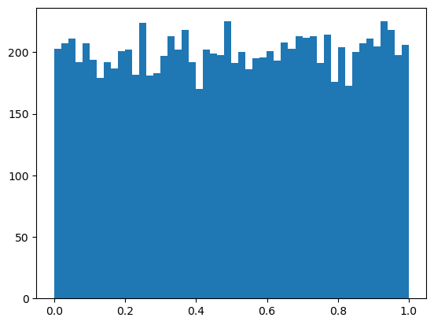

```python
show_uniform_ndarray(uniform_ndarray)
```

## 將原始資料視覺化（續）

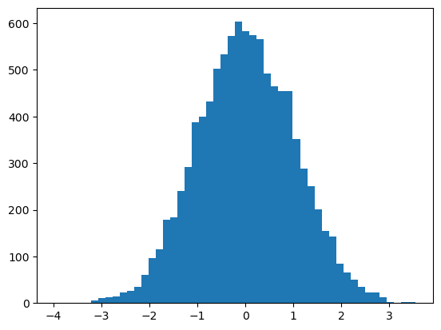

```python
show_normal_ndarray(normal_ndarray)
```

## 將原始資料視覺化（續）

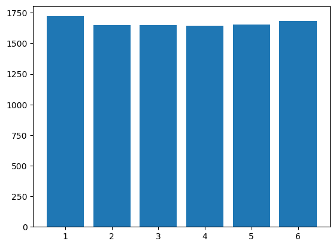

```python
show_randint_ndarray(randint_ndarray)
```

## 好的視覺化要素

- 有資訊價值、簡潔與美觀。
- 經典視覺化：
  - [Charles Minard's map of Napoleon's disastrous Russian campaign of 1812](https://en.wikipedia.org/wiki/Charles_Joseph_Minard#/media/File:Minard.png)
  - [Hans Rosling's 200 Countries, 200 Years, 4 Minutes](https://youtu.be/jbkSRLYSojo)

## 兩種語法

## 新手學習 Matplotlib 的最大挑戰：兩種不同的作圖語法

1. Matlab 風格。
2. 物件導向風格。

## Matlab 風格

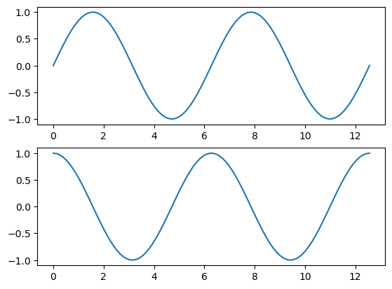

```python
x = np.linspace(0, np.pi*4, 100)
plt.figure()
plt.subplot(2, 1, 1)
plt.plot(x, np.sin(x))
plt.subplot(2, 1, 2)
plt.plot(x, np.cos(x))
plt.show()
```

## Matlab 風格的優缺點

- 優點：指令式語法，比較直觀。
- 缺點：狀態型介面，需要依程式碼順序閱讀才能理解。

## 物件導向風格

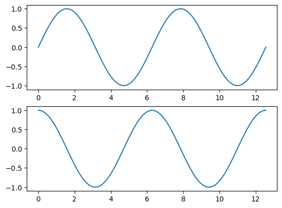

```python
fig, axes = plt.subplots(2, 1)
axes[0].plot(x, np.sin(x))
axes[1].plot(x, np.cos(x))
plt.show()
```

## 物件導向風格的優缺點

- 優點：物件型介面，不需要依程式碼順序閱讀也能理解。
- 缺點：對不熟悉物件導向概念的人不友善。

由於我們在「使用類別組織函數與資料」章節對物件導向概念已經有入門理解，因此採用物件導向風格是最適合的。

## 視覺化五步驟

## 視覺化的標準五步驟

1. 建立 `ndarray`
2. 建立「畫布物件」與「軸物件」。
3. 使用「軸物件」的作圖方法建立主要圖形。
4. 使用「軸物件」的作圖方法添加圖形元素。
5. 顯示或者儲存圖形。

## 建立 `ndarray`

```python
x = np.linspace(0, np.pi*2, 100)
sinx = np.sin(x)
```

## 建立「畫布物件」與「軸物件」

使用 `plt.subplots()` 函數。

```
<class 'matplotlib.figure.Figure'>
<class 'matplotlib.axes._subplots.AxesSubplot'>
```

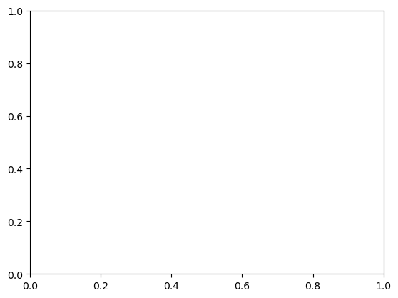

```python
fig, ax = plt.subplots()
print(type(fig))
print(type(ax))
```

## 使用「軸物件」的作圖方法建立主要圖形

`AxesSubplot.plot()` 能夠建立線圖。

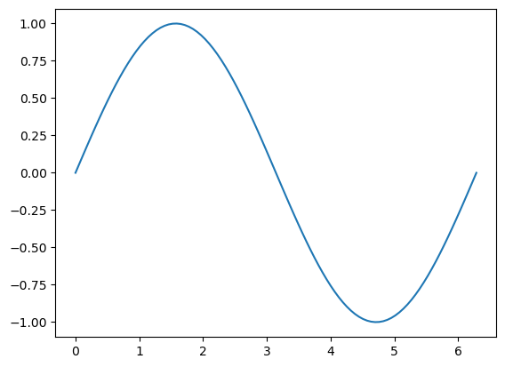

```python
fig = plt.figure()
ax = plt.axes()
ax.plot(x, sinx)
```

## 使用「軸物件」的作圖方法添加圖形元素

```
(-5.0, 5.0)
```

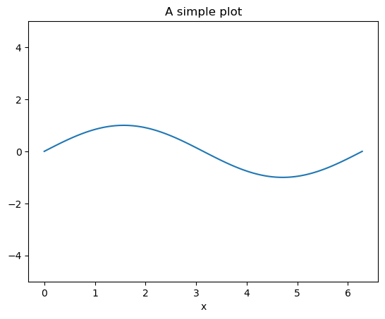

```python
fig = plt.figure()
ax = plt.axes()
ax.plot(x, sinx)
ax.set_title('A simple plot')
ax.set_xlabel('x')
ax.set_ylim(-5, 5)
```

## 顯示圖形

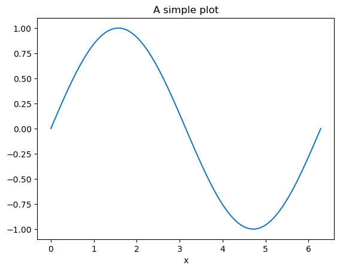

```python
fig = plt.figure()
ax = plt.axes()
ax.plot(x, sinx)
ax.set_title('A simple plot')
ax.set_xlabel('x')
plt.show()
```

## 儲存圖形：可支援的圖片格式

```python
fig = plt.figure()
fig.canvas.get_supported_filetypes()
```

```
{'eps': 'Encapsulated Postscript',
 'jpg': 'Joint Photographic Experts Group',
 'jpeg': 'Joint Photographic Experts Group',
 'pdf': 'Portable Document Format',
 'pgf': 'PGF code for LaTeX',
 'png': 'Portable Network Graphics',
 'ps': 'Postscript',
 'raw': 'Raw RGBA bitmap',
 'rgba': 'Raw RGBA bitmap',
 'svg': 'Scalable Vector Graphics',
 'svgz': 'Scalable Vector Graphics',
 'tif': 'Tagged Image File Format',
 'tiff': 'Tagged Image File Format'}
```

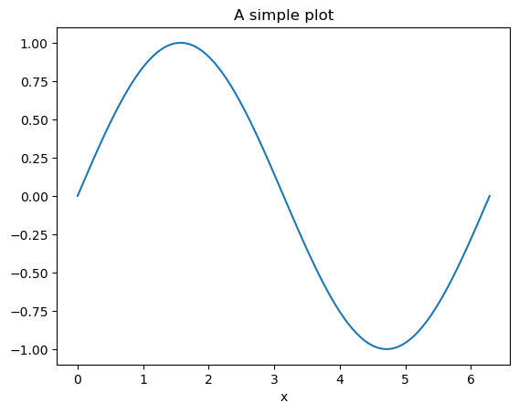

```python
fig = plt.figure()
axes = plt.axes()
axes.plot(x, sinx)
axes.set_title('A simple plot')
axes.set_xlabel('x')
fig.savefig('a_simple_plot.png')
```

## 中文字（非歐美文字）顯示問題解決

## 如何調整中文字型無法顯示的問題

Matplotlib 預設使用的字體不支援中文、日文、韓文等非歐美語系文字。

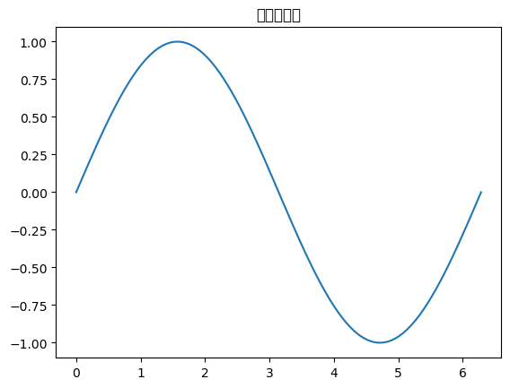

```python
fig = plt.figure()
ax = plt.axes()
ax.plot(x, sinx)
ax.set_title('簡單的圖形')
plt.show()
```

## 指定可以支援中文字體的字型

使用 `matplotlib.font_manager` 的 `FontProperties()` 函數。

```python
from matplotlib.font_manager import FontProperties

msjh = FontProperties(fname="msjh.ttc") # Font supports traditional Chinese
```

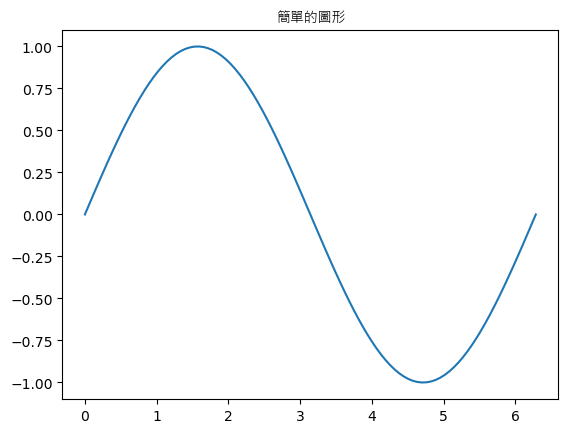

```python
fig = plt.figure()
ax = plt.axes()
ax.plot(x, sinx)
ax.set_title('簡單的圖形', fontproperties=msjh)
plt.show()
```